# Practical Machine learning course project–Exercise manner predict

SherryYe

2016年12月9日

## Introduction

One thing that people regularly do is quantify how much of a particular activity they do, but they rarely quantify how well they do it. In this project, my goal will be to use data from accelerometers on the belt, forearm, arm, and dumbell of 6 participants,and to predict the manner in which they did the exercise.

## Library loading

```r
library(caret)
```

```r
library(rpart)
library(rpart.plot)
library(randomForest)
library(corrplot)
library(psych)
library(kernlab)
```

## Data processing

### Download data

Firsly,we download the raw data from website.

```r
trainUrl <-"https://d396qusza40orc.cloudfront.net/predmachlearn/pml-training.csv"
testUrl <- "https://d396qusza40orc.cloudfront.net/predmachlearn/pml-testing.csv"
trainFile <- "pml-training.csv"
testFile  <- "pml-testing.csv"
```

### Read the data

After downloading the data ,we can read the two csv files into two data frames.

```r
trainRaw<-read.csv("./data/pml-training.csv")
testRaw<-read.csv("./data/pml-testing.csv")
dim(trainRaw)
```

```
## [1] 19622   160
```

```r
dim(testRaw)
```

```
## [1]  20 160
```

### Clean the data

cleaning the data by removing the colnumns with NA to get prepared for later processing.

```r
sum(is.na(trainRaw))
```

```
## [1] 1287472
```

```r
sum(is.na(testRaw))
```

```
## [1] 2000
```

```r
trainRaw <- trainRaw[,colSums(is.na(trainRaw)) == 0]
testRaw <- testRaw[, colSums(is.na(testRaw)) == 0]
```

Next,remove some columns that do not contribute to the accelerometer measurements.

```r
classe <- trainRaw$classe
trainRemove <- grepl("^X|timestamp|window", names(trainRaw))
trainRaw <- trainRaw[, !trainRemove]
trainRaw <- trainRaw[, sapply(trainRaw, is.numeric)]
trainRaw$classe <- classe
testRemove <- grepl("^X|timestamp|window", names(testRaw))
testRaw <- testRaw[, !testRemove]
testRaw <- testRaw[, sapply(testRaw, is.numeric)]
```

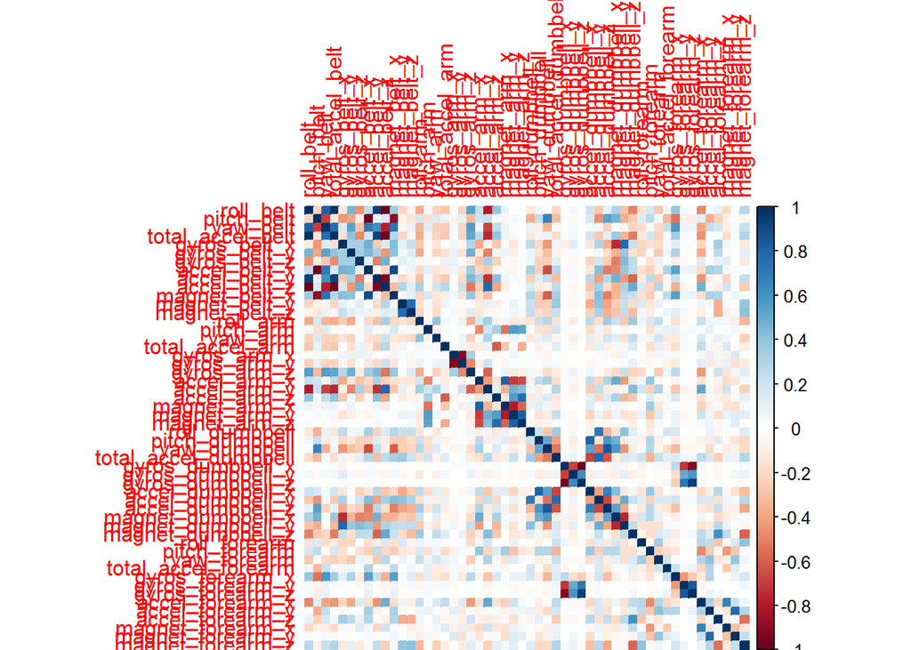

```r
corrPlot <- cor(subset(trainRaw,select=-c(classe)))
corrplot(corrPlot, method="color")
```

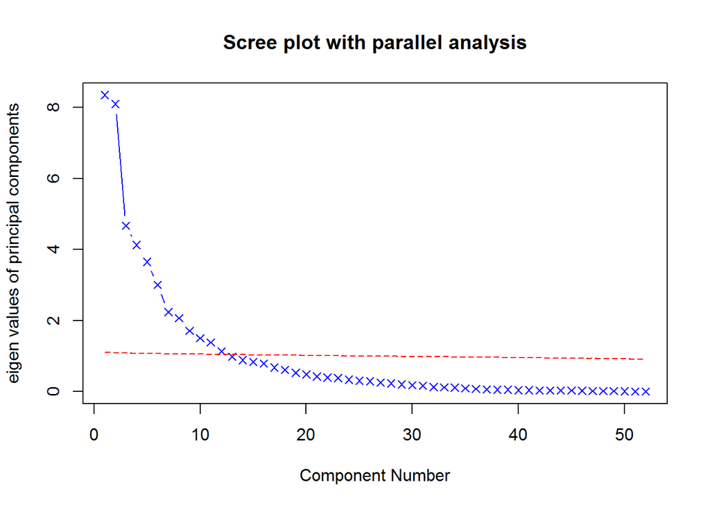

```
## Parallel analysis suggests that the number of factors =  NA  and the number of components =  12
```

```r
fa.parallel(subset(trainRaw,select=-c(classe)),fa="pc",n.iter=100,show.legend=FALSE,main="Scree plot with parallel analysis")
```

### Slice the data

The training set is relatively large ,so we slice the training data into two parts :training set and validation set.The testing set remains the same.

```r
set.seed(950419)
inTrain<-createDataPartition(y=trainRaw$class,p=0.7,list=F)
training<-trainRaw[inTrain,]
validation<-trainRaw[-inTrain,]
testing<-testRaw
```

## Data model

### Train our data

Due to the issue we are faced with,the prediction variance is a discrete one and non-numeric one,we choose **random forest** as the algorithm we apply in this progress.Besides,we use 3-fold cross validation in this algorithm.

```r
modelFit=train(classe~.,method="rf",data=training,trControl=trainControl(method="cv",3),number=250)
```

### Predict in validation set

```r
pred<-predict(modelFit,newdata=validation)
confusionMatrix(validation$classe,pred)
```

```
## Confusion Matrix and Statistics
##
##           Reference
## Prediction    A    B    C    D    E
##          A 1672    2    0    0    0
##          B    9 1129    1    0    0
##          C    0    5 1016    5    0
##          D    1    0    7  954    2
##          E    1    0    0    1 1080
##
## Overall Statistics
##
##                Accuracy : 0.9942
##                  95% CI : (0.9919, 0.996)
##     No Information Rate : 0.286
##     P-Value [Acc > NIR] : < 2.2e-16
##
##                   Kappa : 0.9927
##  Mcnemar's Test P-Value : NA
##
## Statistics by Class:
##
##                      Class: A Class: B Class: C Class: D Class: E
## Sensitivity            0.9935   0.9938   0.9922   0.9938   0.9982
## Specificity            0.9995   0.9979   0.9979   0.9980   0.9996
## Pos Pred Value         0.9988   0.9912   0.9903   0.9896   0.9982
## Neg Pred Value         0.9974   0.9985   0.9984   0.9988   0.9996
## Prevalence             0.2860   0.1930   0.1740   0.1631   0.1839
## Detection Rate         0.2841   0.1918   0.1726   0.1621   0.1835
## Detection Prevalence   0.2845   0.1935   0.1743   0.1638   0.1839
## Balanced Accuracy      0.9965   0.9959   0.9951   0.9959   0.9989
```

```r
accuracy <- postResample(pred, validation$classe)
accuracy
```

```
##  Accuracy     Kappa
## 0.9942226 0.9926908
```

```r
error <- 1 - as.numeric(confusionMatrix(validation$classe, pred)$overall[1])
error
```

```
## [1] 0.0057774
```

Therefore, the estimated accuracy of the model is 99.42% and the estimated out of sample error is 0.58%.

### Visualization

we plot the tree plot to get an intuition of the tree.

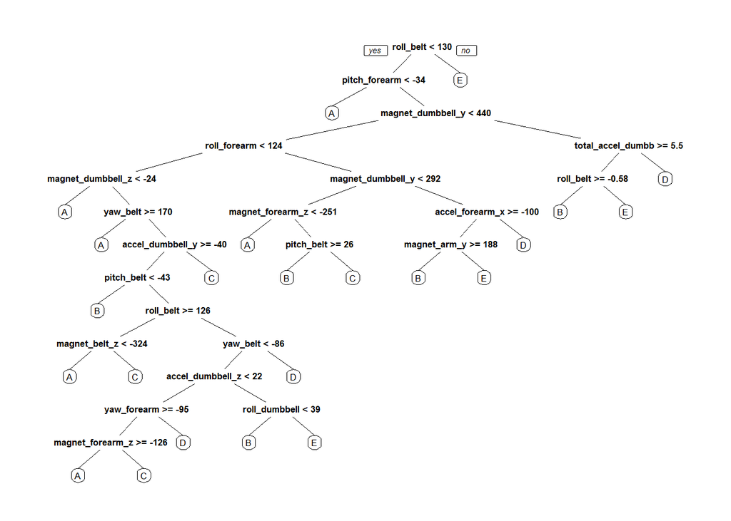

```r
treeModel <- rpart(classe ~ ., data=training, method="class")
prp(treeModel)
```

### Predict in testing set(remove problem.id)

Finally,we predict the testing value.

```r
result <- predict(modelFit,subset(testing,select=-c(problem_id)))
result
```

```
##  [1] B A B A A E D B A A B C B A E E A B B B
## Levels: A B C D E
```